# Project 2

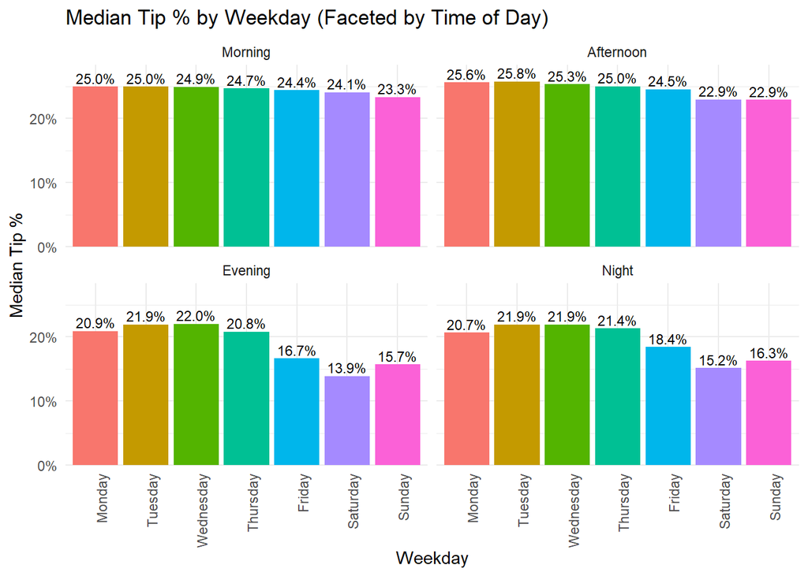

```r
taxi %>%
  group_by(weekday, pickup_time_of_day) %>%
  summarise(
    median_tip = median(tip_percent_fare_amount, na.rm = TRUE),
    .groups = "drop"
  ) %>%
  ggplot(aes(x = weekday, y = median_tip, fill = weekday)) +
  geom_col() +
  geom_text(
    aes(label = scales::percent(median_tip, accuracy = 0.1)),
    vjust = -0.3,
    size = 3
  ) +
  scale_y_continuous(
    labels = scales::percent_format(),
    expand = expansion(mult = c(0, 0.1))
  ) +
  facet_wrap(~ pickup_time_of_day) +
  labs(
    title = "Median Tip % by Weekday (Faceted by Time of Day)",
    x = "Weekday",
    y = "Median Tip %"
  ) +
  theme_minimal() +
  theme(axis.text.x = element_text(angle = 90, hjust = 1),
        legend.position = "none")
```

```r
taxi %>% filter(trip_duration_mins <= 0) %>% arrange(trip_duration_mins)
```

```
## # A tibble: 23,621 × 44
##    VendorID tpep_pickup_datetime tpep_dropoff_datetime passenger_count
##       <int> <dttm>               <dttm>                          <dbl>
##  1        2 2025-11-01 20:58:59  2025-11-01 20:02:32                 1
##  2        2 2025-11-01 20:59:17  2025-11-01 20:03:51                 1
##  3        2 2025-11-01 20:56:27  2025-11-01 20:01:38                 1
##  4        2 2025-11-01 20:56:42  2025-11-01 20:02:01                 1
##  5        1 2025-11-01 20:55:10  2025-11-01 20:02:34                 1
##  6        2 2025-11-01 20:58:42  2025-11-01 20:06:15                 2
##  7        2 2025-11-01 20:53:57  2025-11-01 20:01:57                 1
##  8        1 2025-11-01 20:54:35  2025-11-01 20:03:30                 1
##  9        2 2025-11-01 20:53:52  2025-11-01 20:04:06                 1
## 10        2 2025-11-01 20:58:14  2025-11-01 20:08:36                 2
## # ℹ 23,611 more rows
## # ℹ 40 more variables: trip_distance <dbl>, RatecodeID <int>,
## #   store_and_fwd_flag <chr>, PULocationID <int>, DOLocationID <int>,
## #   payment_type <int>, fare_amount <dbl>, extra <dbl>, mta_tax <dbl>,
## #   tip_amount <dbl>, tolls_amount <dbl>, improvement_surcharge <dbl>,
## #   total_amount <dbl>, congestion_surcharge <dbl>, Airport_fee <dbl>,
## #   cbd_congestion_fee <dbl>, month <fct>, Vendor_name <chr>, …
```

```r
taxi %>% filter(trip_duration_mins > 300)%>% arrange(trip_duration_mins)
```

```
## # A tibble: 606 × 44
##    VendorID tpep_pickup_datetime tpep_dropoff_datetime passenger_count
##       <int> <dttm>               <dttm>                          <dbl>
##  1        1 2025-12-15 12:27:17  2025-12-15 17:29:18                 1
##  2        2 2025-01-07 06:53:07  2025-01-07 11:55:10                 1
##  3        1 2025-09-16 11:45:00  2025-09-16 16:49:08                 1
##  4        2 2025-10-26 13:55:33  2025-10-26 19:00:00                 1
##  5        1 2025-12-02 11:00:00  2025-12-02 16:04:40                 1
##  6        1 2025-09-09 11:59:00  2025-09-09 17:04:06                 1
##  7        1 2025-12-04 11:13:07  2025-12-04 16:18:49                 1
##  8        1 2025-11-05 11:41:28  2025-11-05 16:48:47                 1
##  9        1 2025-09-22 12:30:00  2025-09-22 17:37:43                 1
## 10        1 2025-09-26 11:41:14  2025-09-26 16:56:46                 1
## # ℹ 596 more rows
## # ℹ 40 more variables: trip_distance <dbl>, RatecodeID <int>,
## #   store_and_fwd_flag <chr>, PULocationID <int>, DOLocationID <int>,
## #   payment_type <int>, fare_amount <dbl>, extra <dbl>, mta_tax <dbl>,
## #   tip_amount <dbl>, tolls_amount <dbl>, improvement_surcharge <dbl>,
## #   total_amount <dbl>, congestion_surcharge <dbl>, Airport_fee <dbl>,
## #   cbd_congestion_fee <dbl>, month <fct>, Vendor_name <chr>, …
```

# Section: Tipping Behavior by Trip Duration

## Question: How does median tip percentage vary across different trip duration ranges?

## Answer: Median tip percentages are highest for shorter trips and generally decline as trip duration increases. Trips lasting 0–5 minutes have the highest median tip percentage (34.5%), followed by 5–10 minutes (29.3%) and 10 minutes or less overall, which remain relatively high. Tipping then decreases for longer trips, falling to around 23.5% for 10–20 minutes, 18.0% for 20–30 minutes, 18.5% for 30–60 minutes, and reaching the lowest level for trips over 60 minutes (14.3%). Overall, passengers tend to tip a higher percentage on shorter trips and a lower percentage on longer trips.

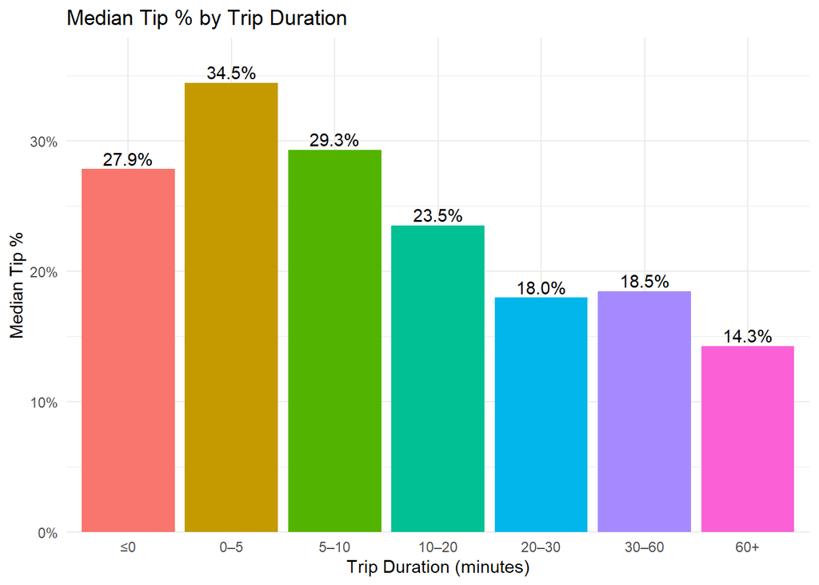

```r
taxi %>%
  mutate(duration_bucket = case_when(
    trip_duration_mins <= 0 ~ "≤0",
    trip_duration_mins <= 5 ~ "0–5",
    trip_duration_mins <= 10 ~ "5–10",
    trip_duration_mins <= 20 ~ "10–20",
    trip_duration_mins <= 30 ~ "20–30",
    trip_duration_mins <= 60 ~ "30–60",
    TRUE ~ "60+"
  )) %>%
  group_by(duration_bucket) %>%
  summarise(
    median_tip = median(tip_percent_fare_amount, na.rm = TRUE),
    .groups = "drop"
  ) %>%
  mutate(duration_bucket = factor(duration_bucket,
    levels = c("≤0","0–5","5–10","10–20","20–30","30–60","60+")
  )) %>%
  ggplot(aes(x = duration_bucket, y = median_tip, fill = duration_bucket)) +
  geom_col() +
  geom_text(
    aes(label = scales::percent(median_tip, accuracy = 0.1)),
    vjust = -0.3
  ) +
  scale_y_continuous(
    labels = scales::percent_format(),
    expand = expansion(mult = c(0, 0.1))
  ) +
  labs(
    title = "Median Tip % by Trip Duration",
    x = "Trip Duration (minutes)",
    y = "Median Tip %"
  ) +
  theme_minimal() +
  theme(legend.position = "none")
```

# Section: Fare Amount by Trip Duration

## Question: How does median fare amount vary across different trip duration ranges?

## Answer: Median fare amount increases steadily as trip duration gets longer. Very short trips have the lowest fares, with 0–5 minutes ($5.80) and 5–10 minutes ($9.30). Fares rise for medium-length trips, reaching about $14.90 for 10–20 minutes and $24.70 for 20–30 minutes. Longer trips show much higher median fares, increasing to $43.50 for 30–60 minutes and peaking at $70.00 for trips over 60 minutes. Overall, longer trip duration is strongly associated with higher fare amounts.

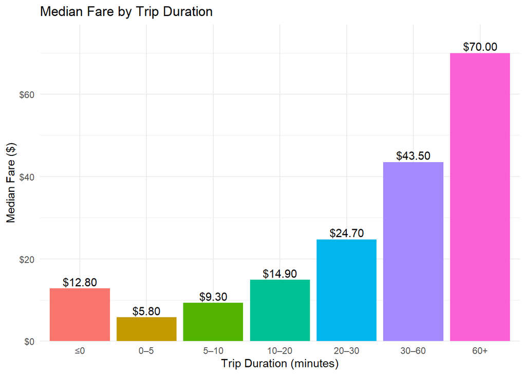

```r
taxi %>%
  mutate(duration_bucket = case_when(
    trip_duration_mins <= 0 ~ "≤0",
    trip_duration_mins <= 5 ~ "0–5",
    trip_duration_mins <= 10 ~ "5–10",
    trip_duration_mins <= 20 ~ "10–20",
    trip_duration_mins <= 30 ~ "20–30",
    trip_duration_mins <= 60 ~ "30–60",
    TRUE ~ "60+"
  )) %>%
  group_by(duration_bucket) %>%
  summarise(
    median_fare = median(fare_amount, na.rm = TRUE),
    .groups = "drop"
  ) %>%
  mutate(duration_bucket = factor(duration_bucket,
    levels = c("≤0","0–5","5–10","10–20","20–30","30–60","60+")
  )) %>%
  ggplot(aes(x = duration_bucket, y = median_fare, fill = duration_bucket)) +
  geom_col() +
  geom_text(
    aes(label = scales::dollar(median_fare)),
    vjust = -0.3
  ) +
  scale_y_continuous(
    labels = scales::dollar_format(),
    expand = expansion(mult = c(0, 0.1))
  ) +
  labs(
    title = "Median Fare by Trip Duration",
    x = "Trip Duration (minutes)",
    y = "Median Fare ($)"
  ) +
  theme_minimal() +
  theme(legend.position = "none")
```

# Section: Tipping Behavior by Trip Distance

## Question: How does median tip percentage vary across different trip distance ranges?

## Answer: Median tip percentages are highest for short-distance trips and generally decline as distance increases. Trips between 0–1 mile have the highest median tip percentage (31.1%), followed by 1–2 miles (26.7%). Tipping then drops for medium-distance trips, reaching 19.8% for 2–5 miles and 11.2% for 5–10 miles. For longer trips, tip percentages recover somewhat but remain lower than very short trips, at about 20.8% for 10–20 miles and 20.5% for 20+ miles. The ≤0 distance group shows 0%, which likely reflects invalid or anomalous records rather than meaningful tipping behavior. Overall, passengers tend to tip a higher percentage on shorter trips, with the lowest tipping observed for mid-range trips around 5–10 miles.

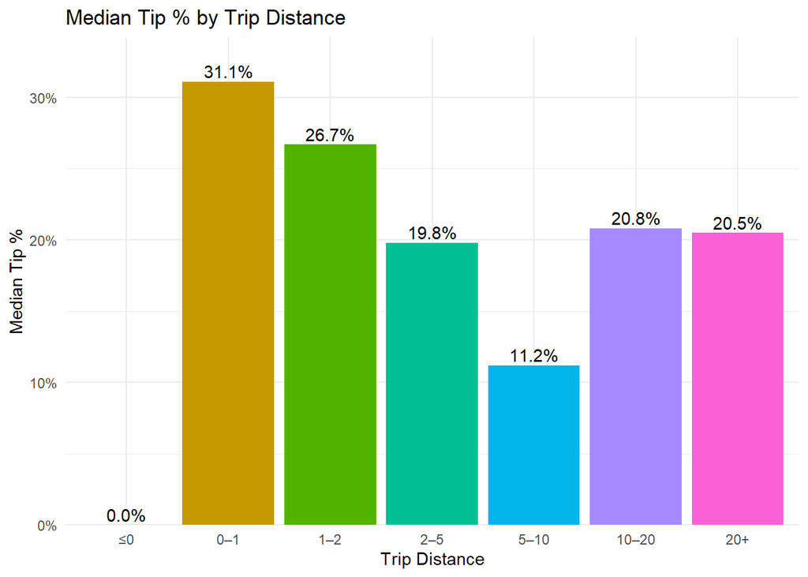

```r
taxi %>%
  mutate(distance_bucket = case_when(
    trip_distance <= 0 ~ "≤0",
    trip_distance <= 1 ~ "0–1",
    trip_distance <= 2 ~ "1–2",
    trip_distance <= 5 ~ "2–5",
    trip_distance <= 10 ~ "5–10",
    trip_distance <= 20 ~ "10–20",
    TRUE ~ "20+"
  )) %>%
  group_by(distance_bucket) %>%
  summarise(
    median_tip = median(tip_percent_fare_amount, na.rm = TRUE),
    .groups = "drop"
  ) %>%
  mutate(distance_bucket = factor(distance_bucket,
    levels = c("≤0","0–1","1–2","2–5","5–10","10–20","20+")
  )) %>%
  ggplot(aes(x = distance_bucket, y = median_tip, fill = distance_bucket)) +
  geom_col() +
  geom_text(
    aes(label = scales::percent(median_tip, accuracy = 0.1)),
    vjust = -0.3
  ) +
  scale_y_continuous(
    labels = scales::percent_format(),
    expand = expansion(mult = c(0, 0.1))
  ) +
  labs(
    title = "Median Tip % by Trip Distance",
    x = "Trip Distance",
    y = "Median Tip %"
  ) +
  theme_minimal() +
  theme(legend.position = "none")
```

# Section: Fare Amount by Trip Distance

## Question: How does median fare amount vary across different trip distance ranges?

## Answer: Median fare amount generally increases as trip distance increases. Very short trips of 0–1 mile have the lowest median fare ($7.20), followed by 1–2 miles ($11.40) and 2–5 miles ($19.10). Fares rise further for longer distances, reaching about $32.80 for 5–10 miles, $59.70 for 10–20 miles, and $70.00 for 20+ miles. The ≤0 distance group shows a relatively high median fare ($20.00), which likely reflects invalid or anomalous trip records rather than a meaningful pattern. Overall, fare amount increases strongly with trip distance.

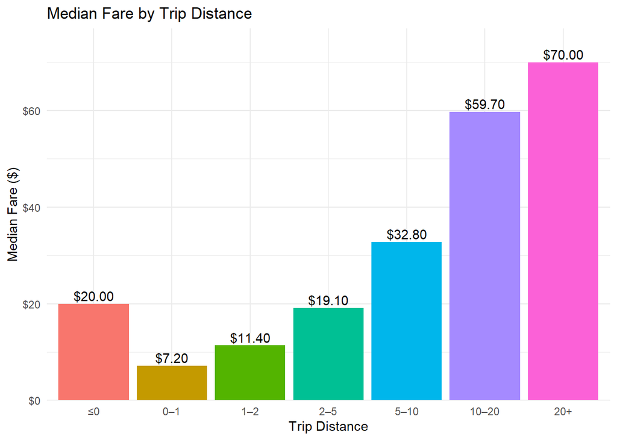

```r
taxi %>%
  mutate(distance_bucket = case_when(
    trip_distance <= 0 ~ "≤0",
    trip_distance <= 1 ~ "0–1",
    trip_distance <= 2 ~ "1–2",
    trip_distance <= 5 ~ "2–5",
    trip_distance <= 10 ~ "5–10",
    trip_distance <= 20 ~ "10–20",
    TRUE ~ "20+"
  )) %>%
  group_by(distance_bucket) %>%
  summarise(
    median_fare = median(fare_amount, na.rm = TRUE),
    .groups = "drop"
  ) %>%
  mutate(distance_bucket = factor(distance_bucket,
    levels = c("≤0","0–1","1–2","2–5","5–10","10–20","20+")
  )) %>%
  ggplot(aes(x = distance_bucket, y = median_fare, fill = distance_bucket)) +
  geom_col() +
  geom_text(
    aes(label = scales::dollar(median_fare)),
    vjust = -0.3
  ) +
  scale_y_continuous(
    labels = scales::dollar_format(),
    expand = expansion(mult = c(0, 0.1))
  ) +
  labs(
    title = "Median Fare by Trip Distance",
    x = "Trip Distance",
    y = "Median Fare ($)"
  ) +
  theme_minimal() +
  theme(legend.position = "none")
```

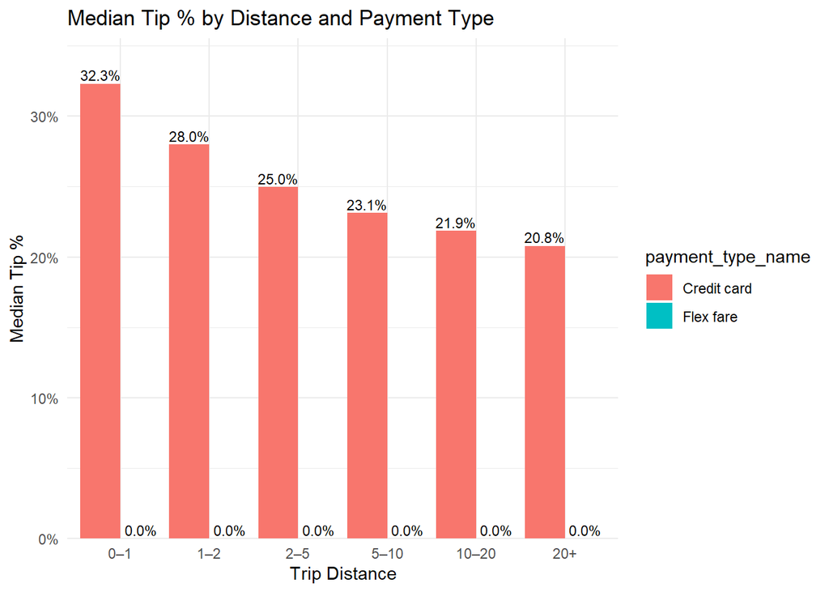

```r
taxi %>%
  filter(trip_distance > 0) %>%
  mutate(distance_bucket = case_when(
    trip_distance <= 1 ~ "0–1",
    trip_distance <= 2 ~ "1–2",
    trip_distance <= 5 ~ "2–5",
    trip_distance <= 10 ~ "5–10",
    trip_distance <= 20 ~ "10–20",
    TRUE ~ "20+"
  )) %>%
  group_by(payment_type_name, distance_bucket) %>%
  summarise(
    median_tip = median(tip_percent_fare_amount, na.rm = TRUE),
    .groups = "drop"
  ) %>%
  mutate(distance_bucket = factor(distance_bucket,
    levels = c("0–1","1–2","2–5","5–10","10–20","20+")
  )) %>%
  ggplot(aes(x = distance_bucket, y = median_tip, fill = payment_type_name)) +
  geom_col(position = "dodge") +
  geom_text(
    aes(label = scales::percent(median_tip, accuracy = 0.1)),
    position = position_dodge(width = 0.9),
    vjust = -0.3,
    size = 3
  ) +
  scale_y_continuous(labels = scales::percent_format(),
                     expand = expansion(mult = c(0, 0.1))) +
  labs(
    title = "Median Tip % by Distance and Payment Type",
    x = "Trip Distance",
    y = "Median Tip %"
  ) +
  theme_minimal()
```

# Section: Tipping Behavior by Trip Distance and Passenger Count

## Question: How does median tip percentage vary by trip distance when broken down by passenger count?

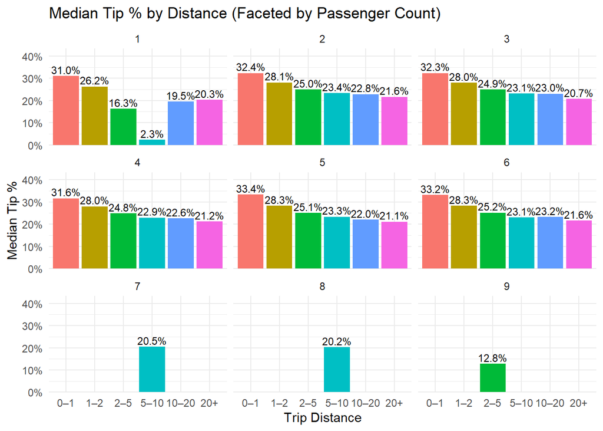

```r
taxi %>%
  filter(trip_distance > 0, passenger_count > 0) %>%
  mutate(distance_bucket = case_when(
    trip_distance <= 1 ~ "0–1",
    trip_distance <= 2 ~ "1–2",
    trip_distance <= 5 ~ "2–5",
    trip_distance <= 10 ~ "5–10",
    trip_distance <= 20 ~ "10–20",
    TRUE ~ "20+"
  )) %>%
  group_by(passenger_count, distance_bucket) %>%
  summarise(
    median_tip = median(tip_percent_fare_amount, na.rm = TRUE),
    .groups = "drop"
  ) %>%
  mutate(distance_bucket = factor(distance_bucket,
    levels = c("0–1","1–2","2–5","5–10","10–20","20+")
  )) %>%
  ggplot(aes(x = distance_bucket, y = median_tip, fill = distance_bucket)) +
  geom_col() +
  geom_text(
    aes(label = scales::percent(median_tip, accuracy = 0.1)),
    vjust = -0.3,
    size = 3
  ) +
  scale_y_continuous(labels = scales::percent_format(),
                     expand = expansion(mult = c(0, 0.3))) +
  facet_wrap(~ passenger_count) +
  labs(
    title = "Median Tip % by Distance (Faceted by Passenger Count)",
    x = "Trip Distance",
    y = "Median Tip %"
  ) +
  theme_minimal() +
  theme(legend.position = "none")
```

# Section: Relationship Between Tip Percentage and Trip Duration

## Question: What is the relationship between tip percentage and trip duration?

## Answer: The scatter plot with a fitted trend line shows a clear negative relationship between tip percentage and trip duration. As trip duration increases, the tip percentage generally decreases. Short trips exhibit a wide range of tipping behavior, including many higher tip percentages, while longer trips tend to cluster at lower tip percentages with less variability. This confirms earlier findings that passengers tend to tip a higher percentage on shorter trips and a lower percentage on longer trips.

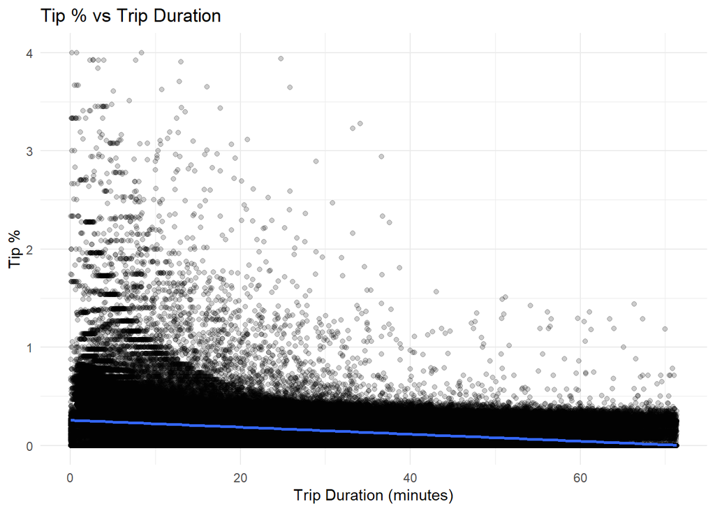

```r
taxi %>%
  filter(
    trip_distance > 0,
    trip_duration_mins > 0,
    #fare_amount > 0,
    tip_percent_fare_amount >= 0,
    tip_percent_fare_amount <= 4
  ) %>%
  filter(
    trip_distance <= quantile(trip_distance, 0.99, na.rm = TRUE),
    trip_duration_mins <= quantile(trip_duration_mins, 0.99, na.rm = TRUE)
    #fare_amount <= quantile(fare_amount, 0.99, na.rm = TRUE)
  ) %>%
  ggplot(aes(x = trip_duration_mins, y = tip_percent_fare_amount)) +
  geom_jitter(alpha = 0.2) +
  geom_smooth( method = 'lm')+
  labs(
    title = "Tip % vs Trip Duration",
    x = "Trip Duration (minutes)",
    y = "Tip %"
  ) +
  theme_minimal()
```

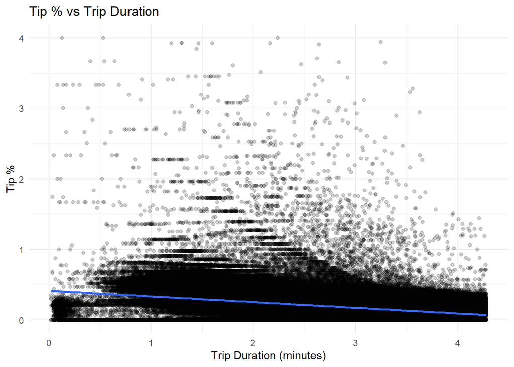

```r
taxi %>%
  filter(
    trip_distance > 0,
    trip_duration_mins > 0,
    #fare_amount > 0,
    tip_percent_fare_amount >= 0,
    tip_percent_fare_amount <= 4
  ) %>%
  filter(
    trip_distance <= quantile(trip_distance, 0.99, na.rm = TRUE),
    trip_duration_mins <= quantile(trip_duration_mins, 0.99, na.rm = TRUE)
    #fare_amount <= quantile(fare_amount, 0.99, na.rm = TRUE)
  ) %>%
  ggplot(aes(x = log1p(trip_duration_mins), y = tip_percent_fare_amount)) +
  geom_jitter(alpha = 0.2) +
  geom_smooth( method = 'lm')+
  labs(
    title = "Tip % vs Trip Duration",
    x = "Trip Duration (minutes)",
    y = "Tip %"
  ) +
  theme_minimal()
```

# Section: Relationship Between Tip Percentage and Trip Distance

## Question: What is the relationship between tip percentage and trip distance?

## Answer: The scatter plot and trend line show a clear negative relationship between tip percentage and trip distance. As trip distance increases, the tip percentage generally decreases. Short-distance trips display a wide spread of tipping behavior, including many higher tip percentages, while longer-distance trips are more concentrated at lower tip percentages with less variability. This reinforces earlier findings that passengers tend to tip a higher percentage on shorter trips and a lower percentage on longer trips.

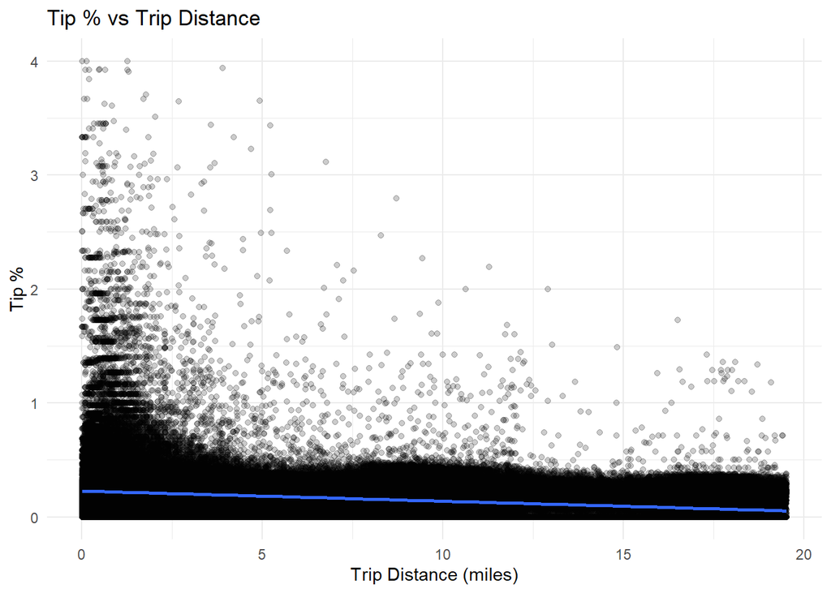

```r
taxi %>%
  filter(
    trip_distance > 0,
    trip_duration_mins > 0,
    #fare_amount > 0,
    tip_percent_fare_amount >= 0,
    tip_percent_fare_amount <= 4
  ) %>%
  filter(
    trip_distance <= quantile(trip_distance, 0.99, na.rm = TRUE),
    trip_duration_mins <= quantile(trip_duration_mins, 0.99, na.rm = TRUE)
    #fare_amount <= quantile(fare_amount, 0.99, na.rm = TRUE)
  ) %>%
  ggplot(aes(x = trip_distance, y = tip_percent_fare_amount)) +
  geom_jitter(alpha = 0.2) +
  geom_smooth( method = 'lm')+
  labs(
    title = "Tip % vs Trip Distance",
    x = "Trip Distance (miles)",
    y = "Tip %"
  ) +
  theme_minimal()
```

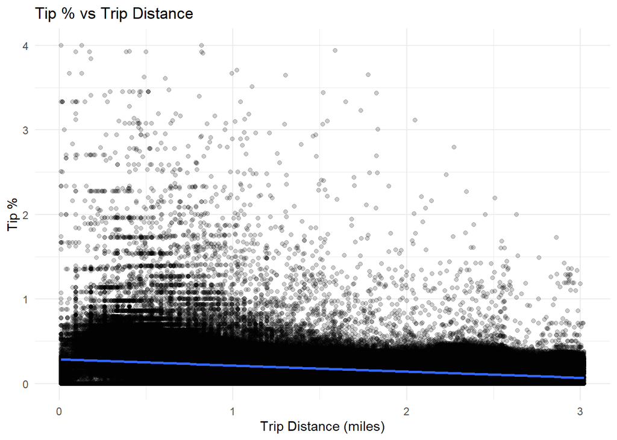

```r
taxi %>%
  filter(
    trip_distance > 0,
    trip_duration_mins > 0,
    #fare_amount > 0,
    tip_percent_fare_amount >= 0,
    tip_percent_fare_amount <= 4
  ) %>%
  filter(
    trip_distance <= quantile(trip_distance, 0.99, na.rm = TRUE),
    trip_duration_mins <= quantile(trip_duration_mins, 0.99, na.rm = TRUE)
    #fare_amount <= quantile(fare_amount, 0.99, na.rm = TRUE)
  ) %>%
  ggplot(aes(x = log1p(trip_distance), y = tip_percent_fare_amount)) +
  geom_jitter(alpha = 0.2) +
  geom_smooth( method = 'lm')+
  labs(
    title = "Tip % vs Trip Distance",
    x = "Trip Distance (miles)",
    y = "Tip %"
  ) +
  theme_minimal()
```

# Section: Relationship Between Tip Percentage and Fare Amount

## Question: What is the relationship between tip percentage and fare amount?

## Answer: The scatter plot indicates a negative relationship between tip percentage and fare amount. As fare amount increases, the tip percentage tends to decline, as shown by the downward-sloping trend line. Lower fare trips exhibit greater variability and often include higher tip percentages, while higher fare trips are more tightly clustered at lower tip percentages. This suggests that riders are less likely to tip a high percentage on more expensive trips, even though the absolute tip amount may still be larger.

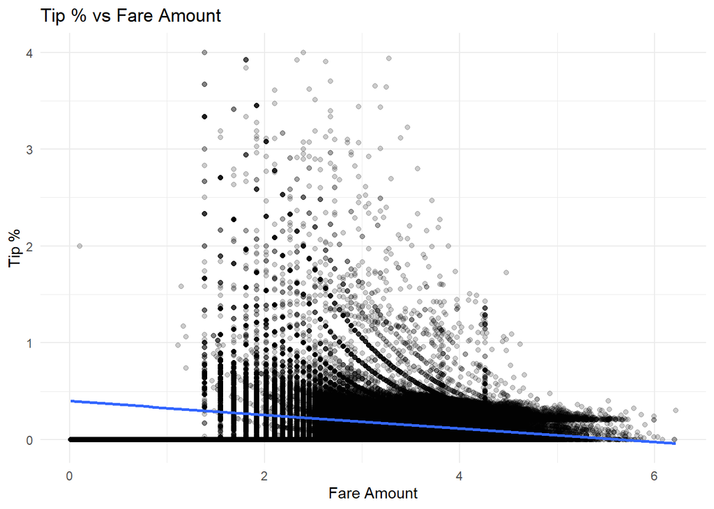

```r
taxi %>%
  filter(
    trip_distance > 0,
    trip_duration_mins > 0,
    tip_percent_fare_amount >= 0,
    tip_percent_fare_amount <= 4
  ) %>%
  filter(
    #trip_distance <= quantile(trip_distance, 0.99, na.rm = TRUE),
    trip_duration_mins <= quantile(trip_duration_mins, 0.99, na.rm = TRUE)
    #fare_amount <= quantile(fare_amount, 0.99, na.rm = TRUE)
  ) %>%
  ggplot(aes(x = log1p(fare_amount), y = tip_percent_fare_amount)) +
  geom_jitter(alpha = 0.2) +
  geom_smooth( method = 'lm')+
  labs(
    title = "Tip % vs Fare Amount",
    x = "Fare Amount",
    y = "Tip %"
  ) +
  theme_minimal()
```

# Section: Predictive Performance of the Tip Percentage Model

## Question: How well does the linear regression model predict tip percentage withour removing outliers?

## Answer: The linear regression model shows moderate predictive accuracy. On the test set, it achieves an RMSE of about 0.422 and an MAE of about 0.149. This means the model’s predictions deviate from the actual tip percentage by about 14.9 percentage points on average, with larger errors reflected in the RMSE. Overall, the model captures some of the variation in tipping behavior, but prediction error remains substantial, suggesting that tip percentage is influenced by additional nonlinear or unobserved factors not fully captured by the model.

```r
set.seed(123)

train_idx <- sample(seq_len(nrow(taxi)), size = 0.8 * nrow(taxi))

summary(taxi)
```

```
##     VendorID     tpep_pickup_datetime          tpep_dropoff_datetime
##  Min.   :1.000   Min.   :2024-12-31 17:51:20   Min.   :2024-12-31 18:00:00
##  1st Qu.:2.000   1st Qu.:2025-04-07 13:26:10   1st Qu.:2025-04-07 13:40:15
##  Median :2.000   Median :2025-07-02 20:28:32   Median :2025-07-02 20:39:55
##  Mean   :1.851   Mean   :2025-07-06 05:07:38   Mean   :2025-07-06 05:25:05
##  3rd Qu.:2.000   3rd Qu.:2025-10-07 03:47:34   3rd Qu.:2025-10-07 04:06:31
##  Max.   :7.000   Max.   :2025-12-31 17:59:36   Max.   :2026-01-01 11:48:24
##
##  passenger_count trip_distance         RatecodeID     store_and_fwd_flag
##  Min.   :0.000   Min.   :0.000e+00   Min.   : 1.00    Length:2030558
##  1st Qu.:1.000   1st Qu.:1.080e+00   1st Qu.: 1.00    Class :character
##  Median :1.000   Median :1.880e+00   Median : 1.00    Mode  :character
##  Mean   :1.216   Mean   :6.234e+00   Mean   : 3.63
##  3rd Qu.:1.000   3rd Qu.:3.670e+00   3rd Qu.: 1.00
##  Max.   :9.000   Max.   :2.741e+05   Max.   :99.00
##  NA's   :1161                        NA's   :477696
##   PULocationID    DOLocationID    payment_type     fare_amount
##  Min.   :  1.0   Min.   :  1.0   Min.   :0.0000   Min.   :  0.01
##  1st Qu.:114.0   1st Qu.:112.0   1st Qu.:1.0000   1st Qu.: 10.00
##  Median :161.0   Median :162.0   Median :1.0000   Median : 14.90
##  Mean   :162.1   Mean   :161.8   Mean   :0.7647   Mean   : 20.17
##  3rd Qu.:233.0   3rd Qu.:234.0   3rd Qu.:1.0000   3rd Qu.: 24.00
##  Max.   :265.0   Max.   :265.0   Max.   :1.0000   Max.   :936.80
##
##      extra          mta_tax          tip_amount       tolls_amount
##  Min.   :-3.25   Min.   :-5.7500   Min.   :  0.000   Min.   :  0.0000
##  1st Qu.: 0.00   1st Qu.: 0.5000   1st Qu.:  0.000   1st Qu.:  0.0000
##  Median : 0.00   Median : 0.5000   Median :  2.750   Median :  0.0000
##  Mean   : 1.23   Mean   : 0.4939   Mean   :  3.408   Mean   :  0.5279
##  3rd Qu.: 2.50   3rd Qu.: 0.5000   3rd Qu.:  4.360   3rd Qu.:  0.0000
##  Max.   :16.19   Max.   :10.5000   Max.   :960.940   Max.   :141.1800
##
##  improvement_surcharge  total_amount     congestion_surcharge  Airport_fee
##  Min.   :0.0000        Min.   :   0.00   Min.   :0.00         Min.   :0.0000
##  1st Qu.:1.0000        1st Qu.:  17.15   1st Qu.:0.00         1st Qu.:0.0000
##  Median :1.0000        Median :  22.60   Median :2.50         Median :0.0000
##  Mean   :0.9803        Mean   :  29.33   Mean   :1.76         Mean   :0.1114
##  3rd Qu.:1.0000        3rd Qu.:  32.00   3rd Qu.:2.50         3rd Qu.:0.0000
##  Max.   :1.0000        Max.   :1041.30   Max.   :2.50         Max.   :6.7500
##
```

[output cut: 41 more lines]

```
##  Length:2030558     Length:2030558     Length:2030558     Length:2030558
##  Class :character   Class :character   Class :character   Class :character
##  Mode  :character   Mode  :character   Mode  :character   Mode  :character
##
##
##
##
##  trip_duration_mins      weekday        pickup_hour    pickup_time_of_day
##  Min.   : -56.45    Monday   :243673   Min.   : 0.00   Morning  :751135
##  1st Qu.:   8.25    Tuesday  :286232   1st Qu.: 7.00   Afternoon:644946
##  Median :  13.60    Wednesday:308331   Median :11.00   Evening  :282852
##  Mean   :  17.45    Thursday :320872   Mean   :10.98   Night    :351625
##  3rd Qu.:  21.55    Friday   :330946   3rd Qu.:15.00
##  Max.   :7859.68    Saturday :316338   Max.   :23.00
##                     Sunday   :224166
```

```r
train <- taxi[train_idx, ]
test  <- taxi[-train_idx, ]

model <- lm(
  tip_percent_fare_amount ~
    trip_distance +
    trip_duration_mins +
    fare_amount +
    payment_type_name +
    pickup_time_of_day +
    weekday +
    pickup_borough +
    dropoff_borough +
    Ratecode_name,
  data = train
)

#summary(model)
#confint(model)

pred <- predict(model, newdata = test)

library(caret)
RMSE(pred, test$tip_percent_fare_amount)
```

```
## [1] 0.4218883
```

```r
MAE(pred, test$tip_percent_fare_amount)
```

```
## [1] 0.1492949
```

## Section: Model Performance After Data Cleaning

## Question: How does the linear regression model perform after cleaning the data?

## Answer: After removing outliers and restricting tip percentages to a reasonable range, the model’s performance improves substantially. The test set results show an RMSE of about 0.098 and an MAE of about 0.067, indicating much smaller prediction errors compared to the earlier model.

## Additionally, the training set metrics (RMSE ≈ 0.098, MAE ≈ 0.067) are very close to the test set results, suggesting no significant overfitting and good generalization. Overall, data cleaning greatly enhances model stability and predictive accuracy, highlighting the importance of handling extreme values in tipping behavior analysis.

```r
taxi_clean <- taxi %>%
  filter(
    trip_distance > 0,
    trip_duration_mins > 0,
    fare_amount > 0,
    tip_percent_fare_amount >= 0,
    tip_percent_fare_amount <= 1
  ) %>%
  filter(
    trip_distance <= quantile(trip_distance, 0.99, na.rm = TRUE),
    trip_duration_mins <= quantile(trip_duration_mins, 0.99, na.rm = TRUE),
    fare_amount <= quantile(fare_amount, 0.99, na.rm = TRUE)
  )

summary(taxi_clean)
```

```
##     VendorID    tpep_pickup_datetime          tpep_dropoff_datetime
##  Min.   :1.00   Min.   :2024-12-31 17:51:20   Min.   :2024-12-31 18:00:00
##  1st Qu.:2.00   1st Qu.:2025-04-05 18:32:30   1st Qu.:2025-04-05 18:48:38
##  Median :2.00   Median :2025-07-01 07:22:03   Median :2025-07-01 07:39:12
##  Mean   :1.79   Mean   :2025-07-05 01:03:54   Mean   :2025-07-05 01:20:12
##  3rd Qu.:2.00   3rd Qu.:2025-10-05 16:55:40   3rd Qu.:2025-10-05 17:12:20
##  Max.   :6.00   Max.   :2025-12-31 17:59:36   Max.   :2025-12-31 18:35:16
##
##  passenger_count trip_distance      RatecodeID     store_and_fwd_flag
##  Min.   :0.000   Min.   : 0.010   Min.   : 1.00    Length:1911250
##  1st Qu.:1.000   1st Qu.: 1.100   1st Qu.: 1.00    Class :character
##  Median :1.000   Median : 1.890   Median : 1.00    Mode  :character
##  Mean   :1.213   Mean   : 3.157   Mean   : 3.11
##  3rd Qu.:1.000   3rd Qu.: 3.560   3rd Qu.: 1.00
##  Max.   :7.000   Max.   :19.510   Max.   :99.00
##  NA's   :1029                     NA's   :438743
##   PULocationID    DOLocationID    payment_type     fare_amount
##  Min.   :  1.0   Min.   :  1.0   Min.   :0.0000   Min.   : 0.01
##  1st Qu.:114.0   1st Qu.:112.0   1st Qu.:1.0000   1st Qu.: 9.62
##  Median :161.0   Median :162.0   Median :1.0000   Median :14.20
##  Mean   :162.6   Mean   :162.2   Mean   :0.7704   Mean   :18.65
##  3rd Qu.:233.0   3rd Qu.:234.0   3rd Qu.:1.0000   3rd Qu.:22.60
##  Max.   :265.0   Max.   :265.0   Max.   :1.0000   Max.   :75.00
##
##      extra           mta_tax          tip_amount      tolls_amount
##  Min.   :-3.250   Min.   :-5.7500   Min.   : 0.000   Min.   : 0.0000
##  1st Qu.: 0.000   1st Qu.: 0.5000   1st Qu.: 0.000   1st Qu.: 0.0000
##  Median : 0.000   Median : 0.5000   Median : 2.750   Median : 0.0000
##  Mean   : 1.274   Mean   : 0.4979   Mean   : 3.214   Mean   : 0.4196
##  3rd Qu.: 2.500   3rd Qu.: 0.5000   3rd Qu.: 4.290   3rd Qu.: 0.0000
##  Max.   :15.000   Max.   :10.5000   Max.   :70.000   Max.   :44.1800
##
##  improvement_surcharge  total_amount    congestion_surcharge  Airport_fee
##  Min.   :0.0000        Min.   :  0.00   Min.   :0.000        Min.   :0.00000
##  1st Qu.:1.0000        1st Qu.: 16.99   1st Qu.:0.000        1st Qu.:0.00000
##  Median :1.0000        Median : 22.26   Median :2.500        Median :0.00000
##  Mean   :0.9836        Mean   : 27.55   Mean   :1.804        Mean   :0.09443
##  3rd Qu.:1.0000        3rd Qu.: 31.00   3rd Qu.:2.500        3rd Qu.:0.00000
##  Max.   :1.0000        Max.   :145.95   Max.   :2.500        Max.   :1.75000
##
```

[output cut: 41 more lines]

```
##  Length:1911250     Length:1911250     Length:1911250     Length:1911250
##  Class :character   Class :character   Class :character   Class :character
##  Mode  :character   Mode  :character   Mode  :character   Mode  :character
##
##
##
##
##  trip_duration_mins      weekday        pickup_hour    pickup_time_of_day
##  Min.   : 0.01667   Monday   :227699   Min.   : 0.00   Morning  :704013
##  1st Qu.: 8.36667   Tuesday  :268622   1st Qu.: 7.00   Afternoon:599457
##  Median :13.48333   Wednesday:288679   Median :11.00   Evening  :272735
##  Mean   :16.30754   Thursday :298976   Mean   :10.98   Night    :335045
##  3rd Qu.:20.96667   Friday   :308562   3rd Qu.:15.00
##  Max.   :71.35000   Saturday :304999   Max.   :23.00
##                     Sunday   :213713
```

```r
set.seed(123)

train_idx_clean <- sample(seq_len(nrow(taxi_clean)), size = 0.8 * nrow(taxi_clean))

train_clean <- taxi_clean[train_idx_clean, ]
test_clean  <- taxi_clean[-train_idx_clean, ]


model_clean <- lm(
  tip_percent_fare_amount ~
    trip_distance +
    trip_duration_mins +
    fare_amount +
    payment_type_name +
    pickup_time_of_day +
    weekday +
    pickup_borough +
    dropoff_borough +
    Ratecode_name,
  data = train_clean
)

summary(model_clean)
```

```
##
## Call:
## lm(formula = tip_percent_fare_amount ~ trip_distance + trip_duration_mins +
##     fare_amount + payment_type_name + pickup_time_of_day + weekday +
##     pickup_borough + dropoff_borough + Ratecode_name, data = train_clean)
##
## Residuals:
##      Min       1Q   Median       3Q      Max
## -0.34701 -0.03619  0.00742  0.04398  0.93554
##
## Coefficients:
##                                   Estimate Std. Error  t value Pr(>|t|)
## (Intercept)                      3.060e-01  1.397e-03  219.086  < 2e-16 ***
## trip_distance                    2.133e-03  6.190e-05   34.456  < 2e-16 ***
## trip_duration_mins              -2.070e-03  1.501e-05 -137.837  < 2e-16 ***
## fare_amount                     -8.910e-04  1.818e-05  -49.016  < 2e-16 ***
## payment_type_nameFlex fare      -2.880e-02  7.090e-04  -40.616  < 2e-16 ***
## pickup_time_of_dayAfternoon      2.901e-03  1.947e-04   14.898  < 2e-16 ***
## pickup_time_of_dayEvening       -1.359e-02  2.590e-04  -52.468  < 2e-16 ***
## pickup_time_of_dayNight         -1.101e-02  2.375e-04  -46.340  < 2e-16 ***
## weekdayTuesday                   1.149e-03  3.123e-04    3.680 0.000233 ***
## weekdayWednesday                 1.286e-03  3.077e-04    4.181 2.90e-05 ***
## weekdayThursday                  6.844e-04  3.057e-04    2.239 0.025161 *
## weekdayFriday                   -3.482e-03  3.043e-04  -11.445  < 2e-16 ***
## weekdaySaturday                 -1.199e-02  3.055e-04  -39.264  < 2e-16 ***
## weekdaySunday                   -1.223e-02  3.315e-04  -36.900  < 2e-16 ***
## pickup_boroughBrooklyn           3.519e-03  1.066e-03    3.302 0.000958 ***
## pickup_boroughEWR               -1.057e-01  2.503e-02   -4.222 2.42e-05 ***
## pickup_boroughManhattan          2.728e-03  9.866e-04    2.765 0.005687 **
## pickup_boroughN/A               -8.810e-02  9.181e-03   -9.595  < 2e-16 ***
## pickup_boroughQueens             1.081e-02  1.035e-03   10.443  < 2e-16 ***
## pickup_boroughStaten Island     -1.569e-03  1.052e-02   -0.149 0.881459
## pickup_boroughUnknown            3.253e-03  2.381e-03    1.366 0.171885
## dropoff_boroughBrooklyn          8.183e-03  9.339e-04    8.762  < 2e-16 ***
## dropoff_boroughEWR               2.741e-02  8.203e-03    3.341 0.000833 ***
## dropoff_boroughManhattan         1.349e-02  8.754e-04   15.415  < 2e-16 ***
## dropoff_boroughN/A               1.205e-02  2.635e-03    4.575 4.77e-06 ***
## dropoff_boroughQueens            1.373e-02  9.310e-04   14.746  < 2e-16 ***
## dropoff_boroughStaten Island     3.236e-03  8.754e-03    0.370 0.711615
## dropoff_boroughUnknown           1.193e-02  2.111e-03    5.650 1.60e-08 ***
## Ratecode_nameNassau/Westchester -7.222e-02  3.970e-03  -18.189  < 2e-16 ***
## Ratecode_nameNegotiated         -6.703e-02  1.665e-03  -40.261  < 2e-16 ***
## Ratecode_nameNewark             -5.052e-02  3.101e-03  -16.288  < 2e-16 ***
## Ratecode_nameStandard           -1.875e-02  7.488e-04  -25.039  < 2e-16 ***
## Ratecode_nameUnknown            -2.188e-01  1.014e-03 -215.877  < 2e-16 ***
## ---
## Signif. codes:  0 '***' 0.001 '**' 0.01 '*' 0.05 '.' 0.1 ' ' 1
##
## Residual standard error: 0.09791 on 1528967 degrees of freedom
## Multiple R-squared:  0.5458, Adjusted R-squared:  0.5458
## F-statistic: 5.742e+04 on 32 and 1528967 DF,  p-value: < 2.2e-16
```

```r
confint(model_clean)
```

```
##                                         2.5 %        97.5 %
## (Intercept)                      3.032336e-01  0.3087080525
## trip_distance                    2.011567e-03  0.0022542212
## trip_duration_mins              -2.098995e-03 -0.0020401387
## fare_amount                     -9.266567e-04 -0.0008553993
## payment_type_nameFlex fare      -3.018744e-02 -0.0274081397
## pickup_time_of_dayAfternoon      2.519671e-03  0.0032830852
## pickup_time_of_dayEvening       -1.409760e-02 -0.0130822803
## pickup_time_of_dayNight         -1.147103e-02 -0.0105400728
## weekdayTuesday                   5.373282e-04  0.0017615784
## weekdayWednesday                 6.832896e-04  0.0018893405
## weekdayThursday                  8.527965e-05  0.0012836022
## weekdayFriday                   -4.078629e-03 -0.0028859206
## weekdaySaturday                 -1.259294e-02 -0.0113955045
## weekdaySunday                   -1.288009e-02 -0.0115808315
## pickup_boroughBrooklyn           1.430433e-03  0.0056071326
## pickup_boroughEWR               -1.547032e-01 -0.0566064623
## pickup_boroughManhattan          7.945856e-04  0.0046620590
## pickup_boroughN/A               -1.060907e-01 -0.0701015147
## pickup_boroughQueens             8.778563e-03  0.0128352336
## pickup_boroughStaten Island     -2.219435e-02  0.0190559168
## pickup_boroughUnknown           -1.414055e-03  0.0079208457
## dropoff_boroughBrooklyn          6.352435e-03  0.0100133668
## dropoff_boroughEWR               1.133196e-02  0.0434852323
## dropoff_boroughManhattan         1.177822e-02  0.0152096121
## dropoff_boroughN/A               6.888185e-03  0.0172152563
## dropoff_boroughQueens            1.190288e-02  0.0155521481
## dropoff_boroughStaten Island    -1.392136e-02  0.0203938810
## dropoff_boroughUnknown           7.791023e-03  0.0160665366
## Ratecode_nameNassau/Westchester -7.999706e-02 -0.0644340385
## Ratecode_nameNegotiated         -7.028955e-02 -0.0637635999
## Ratecode_nameNewark             -5.659410e-02 -0.0444368430
## Ratecode_nameStandard           -2.021743e-02 -0.0172820719
## Ratecode_nameUnknown            -2.207853e-01 -0.2168123006
```

```r
pred_clean <- predict(model_clean, newdata = test_clean)

RMSE(pred_clean, test_clean$tip_percent_fare_amount)
```

```
## [1] 0.09821324
```

```r
MAE(pred_clean, test_clean$tip_percent_fare_amount)
```

```
## [1] 0.06715611
```

```r
# Train predictions
pred_train <- predict(model_clean, newdata = train_clean)

# Train metrics
RMSE(pred_train, train_clean$tip_percent_fare_amount)
```

```
## [1] 0.09791321
```

```r
MAE(pred_train, train_clean$tip_percent_fare_amount)
```

```
## [1] 0.0669151
```

```r
model_improved <- lm(
  tip_percent_fare_amount ~
    log1p(trip_distance) +
    log1p(trip_duration_mins) + I(log1p(trip_duration_mins)^2) +
    log1p(fare_amount) +
    payment_type_name +
    pickup_time_of_day * weekday +
    pickup_borough +
    dropoff_borough +
    Ratecode_name,
  data = train_clean
)

pred_clean_improved <- predict(model_improved, newdata = test_clean)

RMSE(pred_clean_improved, test_clean$tip_percent_fare_amount)
```

```
## [1] 0.09568079
```

```r
MAE(pred_clean_improved, test_clean$tip_percent_fare_amount)
```

```
## [1] 0.06538823
```

```r
# Train predictions
pred_train_improved <- predict(model_improved, newdata = train_clean)

# Train metrics
RMSE(pred_train_improved, train_clean$tip_percent_fare_amount)
```

```
## [1] 0.09542486
```

```r
MAE(pred_train_improved, train_clean$tip_percent_fare_amount)
```

```
## [1] 0.06517572
```